# Lesson 6 Guide

# Lesson 6: Saving and Investment

## Firm’s Decision

Firms have to make a decision about what to use their resources for. There are two things that firms use their resources for.

1. Pay dividends to stock holders
2. Increase capacity to produce more in the future (I)

Firms will choose a level of capital (K) that maximizes profit by reaching the condition $MB = MC$

MB = Expected marginal product of capital (MPK<sup>e</sup>)

MC = User-cost of capital (UC)

$\pi_{max}$ when UC = MPK<sup>e</sup>

## User Cost

We will express user cost in number of output, which is the real cost.

Example: Michael Scott’s Paper Company

- Output: Reams of Paper (Price = $10)
- Capital: Van (Price = $10,000)
- UC = 1,000 reams of paper

### User Cost Factors

User Cost depends on:

- Real Price of capital (P<sub>k</sub>)
- The depreciation rate ($\delta$)
- The real interest rate (r)
- The business tax on revenue ($\tau$)
- Investment Tax Credit (ITC)

### Defining User Cost

Start without considering taxes or tax credits

$$UC = rP_k + \delta P_k$$
$$UC = (r + \delta)P_k$$

Now lets add in $\tau$ (business tax on revenue) Firms will now be losing some % of their benefit (revenue) MPK<sup>e</sup>

At max $\pi$:
$$UC = MPK^e - \tau MPK^e$$
$$UC = (1 - \tau)MPK^e$$
$$\frac{(r + \delta)P_k}{1 - \tau} = \frac{(1 - \tau)MPK^e}{1 - \tau}$$
$$MPK^e = \frac{(r + \delta)P_k}{1 - \tau}$$
$$UC = \frac{(r + \delta)P_k}{1 - \tau}$$

Now let us add in Investment Tax Credit (ITC). Assume ITC is a % of P<sub>k</sub> (real price of capital)

$$P_k = P_k - ITC(P_k)$$
$$P_k = (1 - ITC)P_k$$
Plug this into our user cost we get:
$$UC = \frac{(r + \delta)(1 - ITC)P_k}{(1 - \tau)}$$

### Shifts in User costs

1. Increase in r is increase in UC
2. Increase in $\delta$ is increase in UC
3. Increase in ITC is decrease in UC
4. Increase in P<sub>k</sub> is increase in UC
5. Increase in $\tau$ is increase in UC

## Defining Marginal Benefit MPK<sup>e</sup>

Capital has diminishing marginal returns. This means that as K increases, Y increases, but at a decreasing rate. As K goes up, MPK<sup>e</sup> goes down.

### UC vs MPK<sup>e</sup>

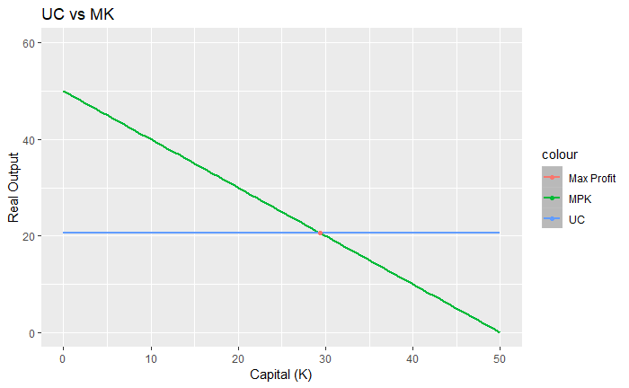

Shifts for UC are all the variables in the euqation of UC, which move it up or down. Shifts for MPK are A and AS. These are total factor productivty (or tech) and “Animal Spirits”. Animal Spirits referrs to investor confidence.

## Investment

### Terminology

I<sub>t</sub> = Gross investment in year t K<sub>t</sub> = capital stock at beginning of year t K<sub>t+1</sub> = capital stock at beginning of year t + 1

- Net investment = $\Delta K$ during year t
  - $K_{t+1} - K_t$
- Net investment = gross investment - depreciation

$$K_{t+1} - K_t = I_t - \delta K_t$$
$$I_t = K_{t+1} - K_t + \delta K_t$$

If we assume that firms are trying to maximize profit $\pi$ then $I_t = K^* - K_t + \delta K_t$ where $K^*$ is the value of k<sub>t+1</sub> that fulfills the condition UC = MPK<sup>e</sup>

- r increases, I<sub>t</sub> decreases

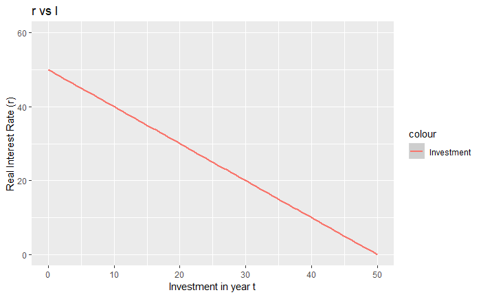

## The Goods Market Equlibrium

- We are in a closed economy so NX = 0
- Savings = Investment

We can go back to our GDP function
$$Y = C + I + G$$
Then rewrite it with investment as our response:
$$I = Y - C - G$$
We know for savings
$$S = S_{pvt} + S_{pub}$$
$$S = ((Y + TR + INT) - (C + T)) + (T - (G + TR + INT))$$
$$S = Y - C - G$$

Therefore savings is equal to investment ($S = I$) when in equilibrium.

Recall in Lesson 5 we learned that when r increases, consumption decreases, so savings must increase. And in this lesson we determined that when r increases, I decreases.

This brings us to our model of Savings vs Investment

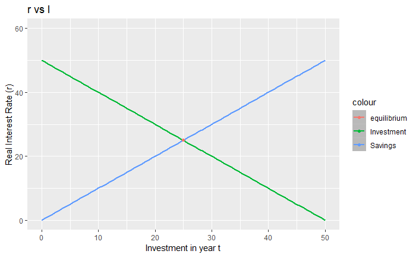

At the equilibrum point above Savings is equal to investment for the given level of r (real interest rate).

## Shifts

The following states how an increase in each factor changes the resposne variable.

### Savings Function

$$S = Y - C - G$$

- Y +
- Y<sub>2</sub> -
- W<sub>1</sub> -
- W<sub>2</sub> -
- T +
- Autonomous Consumption -
- Consumer confidence -
- G -

### Investment Function

$$I = K^* - K_t + \delta K_t$$

- A +
- AS +
- $\tau$ -
- $\delta$ -
- P<sub>k</sub> -
- ITC +